# R Notebook

```r
library(tidyverse)
library(lubridate)
library(MASS)
library(tseries)
library(forecast)
library(fable)
library(fabletools)
library(tsibble)
library(tsibbledata)
library(feasts)
```

### In order to try and validate the model I will take out the last 4 years of data and train the model on the first 20 years only

```r
monthly_train <- monthly %>%
  filter(year_month < "2012-01-01")

monthly_test <- monthly %>%
  filter(year_month >= "2012-01-01")
```

```r
# Taking logs of data to smooth the volatility of the data

log_monthly_train <- log(monthly_train$num_fires)
```

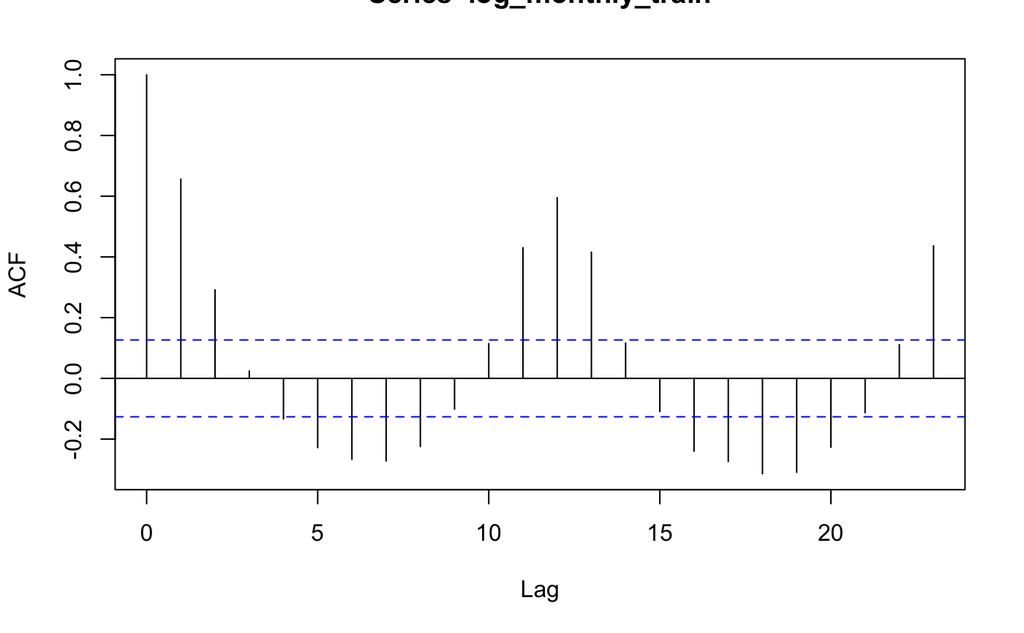

```r
# Autocorrelation plot to look for stationarity

acf(log_monthly_train)
```

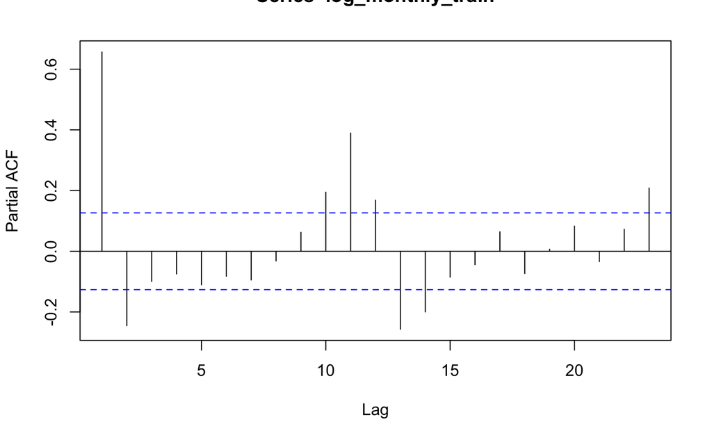

```r
# Partial autocorrelation plot to look for stationarity

pacf(log_monthly_train)
```

**Definitely some repeating patterns in the lag plots which is likely to be some kind of seasonal variation.**

```r
# Using a Dickey-Fuller test to validate any stationarity.

adf.test(log_monthly_train)
```

```
p-value smaller than printed p-value
```

```
    Augmented Dickey-Fuller Test

data:  log_monthly_train
Dickey-Fuller = -7.7134, Lag order = 6, p-value = 0.01
alternative hypothesis: stationary
```

```r
# Decomposing the time series data to examine any seasonal trends

arima_log_monthly <- ts(log_monthly_train, start = c(1992,01), frequency = 12)
components <- decompose(arima_log_monthly)
components
```

```
$x
          Jan      Feb      Mar      Apr      May      Jun      Jul      Aug
1992 8.143227 8.806724 9.127285 8.941415 9.070388 8.903136 8.915298 8.938138
1993 7.185387 8.472823 8.578288 8.821437 8.708144 8.843759 9.058703 8.960725
1994 8.090709 8.601534 9.350450 9.167537 8.837971 8.740497 9.369052 9.105979
1995 7.256297 8.708309 9.224342 9.209340 8.665613 8.504108 9.030855 8.870803
1996 8.081166 9.263976 9.172950 9.203718 8.804325 8.700847 9.174610 9.122274
1997 7.848934 8.214736 8.949495 9.236106 8.820995 8.372630 8.917445 8.714239
1998 7.087574 7.947679 8.777093 8.969542 8.466952 8.852522 9.247443 9.085684
1999 8.179760 8.692154 9.287579 9.276128 8.735686 8.714403 8.859363 9.422302
2000 8.549273 9.218507 9.363233 8.996776 8.994793 9.010669 9.375007 9.513034
2001 8.583543 8.814182 8.802673 9.169831 9.137662 8.722254 9.197356 9.007857
2002 8.183956 9.183791 9.147081 9.061028 8.915567 8.835065 9.274910 9.049115
2003 8.363342 7.975908 8.776321 9.198369 8.564458 8.573952 9.241839 9.116469
2004 8.196712 8.290794 9.458528 9.334326 8.620291 8.832296 9.060680 8.837246
```

[output cut: 191 more lines]

**Definitely some seasonal trend in that data, but let’s have a look at a plot to make sure**

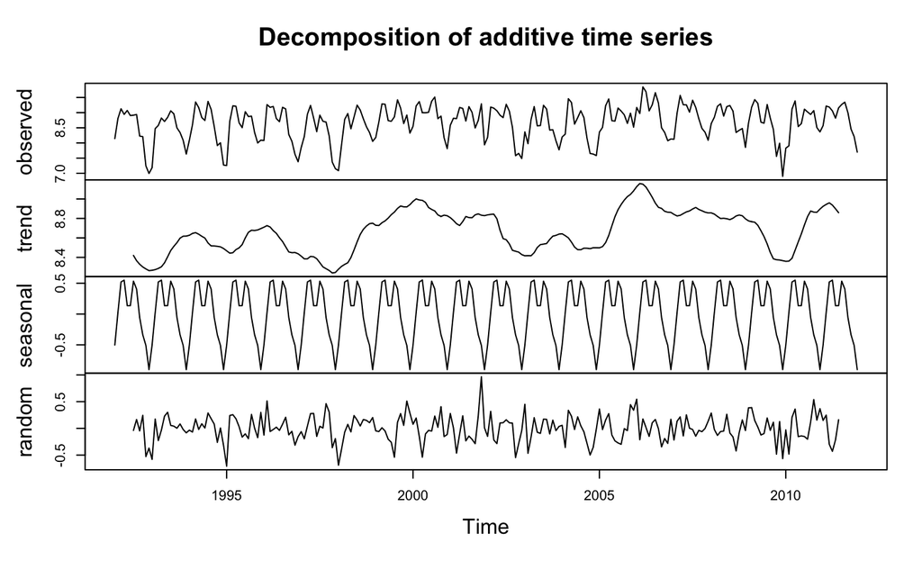

```r
plot(components)
```

**The repeating seasonal trends can be seen very clearly in this plot.**

```r
# Using auto.arima to look at the best ARIMA configuration

fit_log_monthly <- auto.arima(arima_log_monthly, trace = TRUE, test = "kpss", ic = "bic")
```

```
 Fitting models using approximations to speed things up...

 ARIMA(2,0,2)(1,1,1)[12] with drift         : Inf
 ARIMA(0,0,0)(0,1,0)[12] with drift         : 348.5387
 ARIMA(1,0,0)(1,1,0)[12] with drift         : 192.1877
 ARIMA(0,0,1)(0,1,1)[12] with drift         : 191.4947
 ARIMA(0,0,0)(0,1,0)[12]                    : 343.4736
 ARIMA(0,0,1)(0,1,0)[12] with drift         : 301.9043
 ARIMA(0,0,1)(1,1,1)[12] with drift         : 182.9255
 ARIMA(0,0,1)(1,1,0)[12] with drift         : 223.3043
 ARIMA(0,0,1)(2,1,1)[12] with drift         : 188.9437
 ARIMA(0,0,1)(1,1,2)[12] with drift         : 178.8528
 ARIMA(0,0,1)(0,1,2)[12] with drift         : 196.3628
 ARIMA(0,0,1)(2,1,2)[12] with drift         : Inf
 ARIMA(0,0,0)(1,1,2)[12] with drift         : 224.1885
 ARIMA(1,0,1)(1,1,2)[12] with drift         : 144.6941
 ARIMA(1,0,1)(0,1,2)[12] with drift         : 154.1804
 ARIMA(1,0,1)(1,1,1)[12] with drift         : 141.7012
 ARIMA(1,0,1)(0,1,1)[12] with drift         : 151.093
 ARIMA(1,0,1)(1,1,0)[12] with drift         : 181.6344
 ARIMA(1,0,1)(2,1,1)[12] with drift         : 155.0015
 ARIMA(1,0,1)(0,1,0)[12] with drift         : 265.9567
 ARIMA(1,0,1)(2,1,0)[12] with drift         : 173.6303
 ARIMA(1,0,1)(2,1,2)[12] with drift         : 149.0212
 ARIMA(1,0,0)(1,1,1)[12] with drift         : 144.9832
 ARIMA(2,0,1)(1,1,1)[12] with drift         : Inf
 ARIMA(1,0,2)(1,1,1)[12] with drift         : 147.1142
 ARIMA(0,0,0)(1,1,1)[12] with drift         : 230.9174
 ARIMA(0,0,2)(1,1,1)[12] with drift         : 171.7857
 ARIMA(2,0,0)(1,1,1)[12] with drift         : Inf
 ARIMA(1,0,1)(1,1,1)[12]                    : 136.6523
 ARIMA(1,0,1)(0,1,1)[12]                    : 148.4509
 ARIMA(1,0,1)(1,1,0)[12]                    : 176.3221
 ARIMA(1,0,1)(2,1,1)[12]                    : 151.3531
 ARIMA(1,0,1)(1,1,2)[12]                    : 140.1211
 ARIMA(1,0,1)(0,1,0)[12]                    : 260.6772
 ARIMA(1,0,1)(0,1,2)[12]                    : 151.0959
 ARIMA(1,0,1)(2,1,0)[12]                    : 168.4562
 ARIMA(1,0,1)(2,1,2)[12]                    : 145.6231
 ARIMA(0,0,1)(1,1,1)[12]                    : 183.3273
 ARIMA(1,0,0)(1,1,1)[12]                    : 141.5757
 ARIMA(2,0,1)(1,1,1)[12]                    : 139.0441
 ARIMA(1,0,2)(1,1,1)[12]                    : 142.0772
 ARIMA(0,0,0)(1,1,1)[12]                    : 236.0938
 ARIMA(0,0,2)(1,1,1)[12]                    : 171.0962
 ARIMA(2,0,0)(1,1,1)[12]                    : 133.6443
 ARIMA(2,0,0)(0,1,1)[12]                    : 150.1223
 ARIMA(2,0,0)(1,1,0)[12]                    : 179.6441
 ARIMA(2,0,0)(2,1,1)[12]                    : 154.2109
 ARIMA(2,0,0)(1,1,2)[12]                    : 138.9822
 ARIMA(2,0,0)(0,1,0)[12]                    : 261.5281
 ARIMA(2,0,0)(0,1,2)[12]                    : 152.5986
 ARIMA(2,0,0)(2,1,0)[12]                    : 170.3289
 ARIMA(2,0,0)(2,1,2)[12]                    : 151.322
 ARIMA(3,0,0)(1,1,1)[12]                    : Inf
 ARIMA(3,0,1)(1,1,1)[12]                    : Inf

 Now re-fitting the best model(s) without approximations...

 ARIMA(2,0,0)(1,1,1)[12]                    : 124.4327

 Best model: ARIMA(2,0,0)(1,1,1)[12]
```

```r
fit_log_monthly
```

```
Series: arima_log_monthly
ARIMA(2,0,0)(1,1,1)[12]

Coefficients:
         ar1     ar2     sar1     sma1
      0.4582  0.2159  -0.1199  -0.8263
s.e.  0.0645  0.0647   0.0809   0.0607

sigma^2 estimated as 0.08488:  log likelihood=-48.64
AIC=107.29   AICc=107.56   BIC=124.43
```

**auto.arima has chosen the best model with the lowest BIC.**

```r
# Calculated Confidence Intervals

confint(fit_log_monthly)
```

```
           2.5 %      97.5 %
ar1   0.33182713  0.58451378
ar2   0.08895941  0.34276300
sar1 -0.27841855  0.03868241
sma1 -0.94533606 -0.70724822
```

### Now making forecasts for last 4 years

```r
forecast_log_monthly <- forecast(fit_log_monthly, h = 48)
forecast_log_monthly
```

|  | Point Forecast | Lo 80 | Hi 80 | Lo 95 | Hi 95 |
| --- | --- | --- | --- | --- | --- |
| Jan 2012 | 8.283573 | 7.910171 | 8.656974 | 7.712504 | 8.854641 |
| Feb 2012 | 8.644557 | 8.233832 | 9.055283 | 8.016407 | 9.272708 |
| Mar 2012 | 9.249277 | 8.808856 | 9.689698 | 8.575712 | 9.922843 |
| Apr 2012 | 9.274813 | 8.820919 | 9.728708 | 8.580642 | 9.968985 |
| May 2012 | 8.789071 | 8.327358 | 9.250784 | 8.082942 | 9.495200 |
| Jun 2012 | 8.841597 | 8.375678 | 9.307515 | 8.129036 | 9.554158 |
| Jul 2012 | 9.232491 | 8.764220 | 9.700763 | 8.516332 | 9.948650 |
| Aug 2012 | 9.058913 | 8.589339 | 9.528488 | 8.340761 | 9.777065 |
| Sep 2012 | 8.633884 | 8.163583 | 9.104185 | 7.914621 | 9.353148 |
| Oct 2012 | 8.363365 | 7.892659 | 8.834070 | 7.643483 | 9.083246 |

[output cut: 38 more lines]

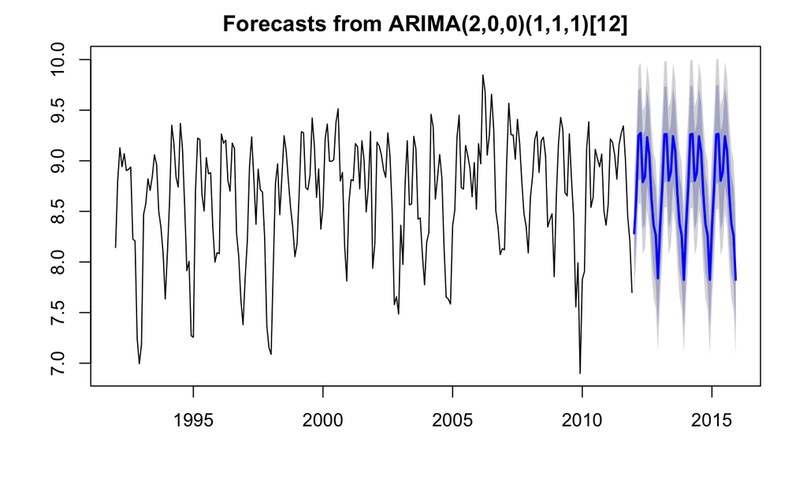

```r
plot(forecast_log_monthly)
```

**ARIMA seems to have only taken the seasonal variation into account and not any trend.**

```r
# Creating the logs of the actual test data

log_monthly_test <- monthly_test %>%
  mutate(num_fires = log(num_fires))
```

```r
# Getting the point forecast out of the forecast list and making it a column in the test set.

forecast_df <- as.tibble(forecast_log_monthly)
```

```
`as.tibble()` is deprecated as of tibble 2.0.0.
Please use `as_tibble()` instead.
The signature and semantics have changed, see `?as_tibble`.
```

```r
log_monthly_test$forecast <- forecast_df$`Point Forecast`

log_monthly_test
```

| year_month | num_fires | forecast |
| --- | --- | --- |
| 2012-01-01 | 8.318254 | 8.283573 |
| 2012-02-01 | 8.298540 | 8.644557 |
| 2012-03-01 | 8.993552 | 9.249277 |
| 2012-04-01 | 8.958797 | 9.274813 |
| 2012-05-01 | 8.674368 | 8.789071 |
| 2012-06-01 | 8.850661 | 8.841597 |
| 2012-07-01 | 9.395242 | 9.232491 |
| 2012-08-01 | 9.029777 | 9.058913 |
| 2012-09-01 | 8.533067 | 8.633884 |
| 2012-10-01 | 8.206856 | 8.363365 |

[output cut: 38 more lines]

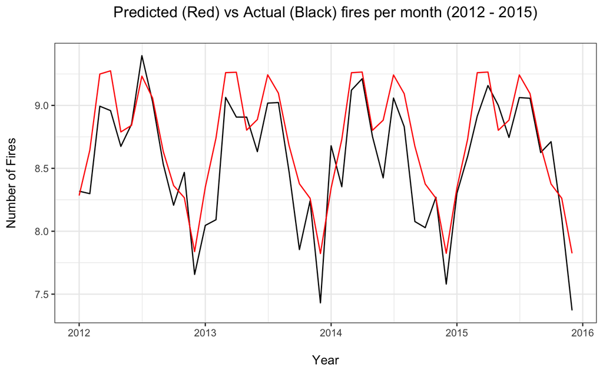

```r
# Plotting actual vs predicted values for 2011-2015


log_monthly_test %>%
  ggplot(aes(x = year_month)) +
  geom_line(aes(y = num_fires), col = "black") +
  geom_line(aes(y = forecast), col = "red") +
  ggtitle("Predicted (Red) vs Actual (Black) fires per month (2012 - 2015)\n") +
  labs(x = "\nYear", y = "Number of Fires\n") +
  theme_bw() +
  theme(plot.title = element_text(hjust = 0.5))
```

```r
NA
```

**The SARIMA model works pretty well when compared with the actual last 4 years worth of data. It clearly has understood the seasonal variation which is present and has predicted values with a reasonable accuracy. It still shows a double peak each year, which I assumed earlier when looking at the month of year data could be due to coinciding with school Spring and Summer breaks. This model also does not support the hypothesis that there is a general increasing or decreasing trend of fires over the reporting period, so I am happy to accept that apart from local environmental, human interaction, climate or other external factors making some variations each year there doesn’t seem to be any general trend present at all.**

### Checking the accuracy of the model to real data.

```r
# Taking the exponentials to return from log figures to normal data

forecast_log_monthly_extracted <- as.numeric(forecast_log_monthly$mean)
forecast_monthly <- exp(forecast_log_monthly_extracted)
forecast_monthly
```

```
 [1]  3958.311  5679.153 10397.050 10665.969  6562.133  6916.027 10223.981
 [8]  8594.804  5618.861  4287.094  3892.262  2534.917  4229.257  6250.793
[15] 10516.071 10545.899  6657.984  7241.405 10331.674  8934.478  5888.378
[22]  4345.943  3872.957  2496.602  4200.307  6184.275 10507.992 10564.922
[29]  6648.632  7203.399 10320.621  8894.298  5856.008  4339.182  3875.490
[36]  2501.272  4203.902  6192.361 10509.150 10562.782  6649.819  7207.998
[43] 10322.004  8899.142  5859.897  4340.002  3875.193  2500.715
```

```r
# Making a dataframe to compare the last 4 years of predicted data against the actual data

check_data <- data.frame(monthly_test, forecast_monthly)

check_data <- check_data %>%
  rename(actual_data = num_fires, predicted_data = forecast_monthly)
```

```r
# Adding an absolute error column to the dataframe

check_data <- check_data %>%
  mutate(absolute_error = abs(actual_data - predicted_data))

check_data
```

| year_month | actual_data | predicted_data | absolute_error |
| --- | --- | --- | --- |
| 2012-01-01 | 4098 | 3958.311 | 139.68924 |
| 2012-02-01 | 4018 | 5679.153 | 1661.15279 |
| 2012-03-01 | 8051 | 10397.050 | 2346.05032 |
| 2012-04-01 | 7776 | 10665.969 | 2889.96874 |
| 2012-05-01 | 5851 | 6562.133 | 711.13305 |
| 2012-06-01 | 6979 | 6916.027 | 62.97330 |
| 2012-07-01 | 12031 | 10223.981 | 1807.01890 |
| 2012-08-01 | 8348 | 8594.804 | 246.80400 |
| 2012-09-01 | 5080 | 5618.861 | 538.86050 |
| 2012-10-01 | 3666 | 4287.094 | 621.09448 |

[output cut: 38 more lines]

```r
# Finding the mean of number of fires for all years

mean_fires <- monthly %>%
  summarise(mean_fires = mean(num_fires))
```

```r
# Taking the mean of the absolute error

mean_error <- check_data %>%
  summarise(mean_error = mean(absolute_error))
```

```r
# Percentage error between monthly fires mean and mean absolute monthly error

mean_error / mean_fires
```

| mean_error |
| --- |
| 0.1916462 |

**Using a absolute mean error method the SARIMA model only has calculated error of 0.19, which is a quite reasonable figure.**